# Lab 2

[Link to my Github Repository](https://github.com/bigturtle13/GSB544/tree/main/Week%202)

0. Import the data and declare your package dependencies.

```python
import pandas as pd
import numpy as np
import calendar
df = pd.read_csv('/Users/amritdhillon/Desktop/GSB544/Week 2/Lab2/avocado-updated-2020.csv')
```

1. Briefly describe the data set. What information does it contain?

This dataset contains data on avocado sales, prices, and volume across different U.S. regions from around January 2015 to May 2020. Data in the dataset provides information like but not limited to the date of the observation, the average price of an avocado, different totals of avocados sold(# of avocados, bags, etc.), the type of avocado, and where the observation was for.

2. Clean the data in any way you see fit.

```python
#dfclean = df

#rename columns for avocado size(hass size)
dfclean = df.rename(columns={'4046':'Shass','4225':'Lhass','4770':'Xlhass'})

#turns dates to datetime format using pandas
dfclean['date'] = pd.to_datetime(dfclean['date'], errors='coerce')

#Total U.S. df
dfus = dfclean[dfclean['geography'] == 'Total U.S.']

#drop Total U.S. values from dfclean to avoid double counting
dfclean = dfclean[dfclean['geography'] != 'Total U.S.']
```

```python
#Cities column

exclude_list = ['California','South Carolina','New York','Midsouth','Northeast','Northern New England','Southeast','Total U.S.','West','West Tex/New Mexico','South Central','Great Lakes','Plains']

dfclean['City'] = dfclean['geography'].where(~dfclean['geography'].isin(exclude_list))
```

```python
#states column

ca_cities = ['Los Angeles', 'San Diego', 'San Francisco', 'Sacramento']
fl_cities = ['Miami/Ft. Lauderdale', 'Orlando', 'Tampa', 'Jacksonville']
tx_cities = ['Dallas/Ft. Worth', 'Houston']
ny_cities = ['Albany', 'Buffalo/Rochester','Syracuse']
wa_cities = ['Seattle', 'Spokane']
or_cities = ['Portland']
in_cities = ['Indianapolis']
il_cities = ['Chicago']
nv_cities = ['Las Vegas']
az_cities = ['Phoenix/Tucson']
co_cities = ['Denver']
ga_cities = ['Atlanta']
ky_cities = ['Louisville']
laal_cities = ['New Orleans/Mobile']
mi_cities = ['Detroit','Grand Rapids']
nc_cities = ['Charlotte','Raleigh/Greensboro']
oh_cities = ['Cincinnati/Dayton', 'Columbus']
pa_cities = ['Philadelphia', 'Pittsburgh', 'Harrisburg/Scranton']
ma_cities = ['Boston']
ct_cities = ['Hartford/Springfield']
mdva_cities = ['Baltimore/Washington', 'Richmond/Norfolk']
tn_cities = ['Nashville']
id_cities = ['Boise']
mo_cities = ['St. Louis']
va_cities = ['Roanoke']
sc_cities = []

#basically sets the new state column to the value of x if the current cell has a value from the specified list
def assign_state(x):
    # California
    if x in ca_cities or x == 'California':
        return 'California'
    # Florida
    elif x in fl_cities or x == 'Florida':
        return 'Florida'
    # Texas
    elif x in tx_cities or x == 'Texas':
        return 'Texas'
    # New York
    elif x in ny_cities or x == 'New York':
        return 'New York'
    # South Carolina
    elif x in sc_cities or x == 'South Carolina':
        return 'South Carolina'
     #Illinois
    elif x in il_cities or x == 'Illinois':
        return 'Illinois'
    # Washington
    elif x in wa_cities or x == 'Washington':
        return 'Washington'
    # Oregon
    elif x in or_cities or x == 'Oregon':
        return 'Oregon'
    # Nevada
    elif x in nv_cities or x == 'Nevada':
        return 'Nevada'
    # Arizona
    elif x in az_cities or x == 'Arizona':
        return 'Arizona'
    #Indiana
    elif x in in_cities or x == 'Indiana':
        return 'Indiana'
    # Colorado
    elif x in co_cities or x == 'Colorado':
        return 'Colorado'
    # Georgia
    elif x in ga_cities or x == 'Georgia':
        return 'Georgia'
    # Kentucky
    elif x in ky_cities or x == 'Kentucky':
        return 'Kentucky'
    # Louisiana / Alabama
    elif x in laal_cities or x in ['Louisiana', 'Alabama']:
        return 'Louisiana/Alabama'
    # Michigan
    elif x in mi_cities or x == 'Michigan':
        return 'Michigan'
    # North Carolina
    elif x in nc_cities or x == 'North Carolina':
        return 'North Carolina'
    # Ohio
    elif x in oh_cities or x == 'Ohio':
        return 'Ohio'
    # Pennsylvania
    elif x in pa_cities or x == 'Pennsylvania':
        return 'Pennsylvania'
    # Massachusetts
    elif x in ma_cities or x == 'Massachusetts':
        return 'Massachusetts'
    # Connecticut
    elif x in ct_cities or x == 'Connecticut':
        return 'Connecticut'
    # Maryland / Virginia shared metros
    elif x in mdva_cities or x in ['Maryland', 'Virginia']:
        return 'Maryland/Virginia'
    # Tennessee
    elif x in tn_cities or x == 'Tennessee':
        return 'Tennessee'
    # Idaho
    elif x in id_cities or x == 'Idaho':
        return 'Idaho'
    # Missouri
    elif x in mo_cities or x == 'Missouri':
        return 'Missouri'
    # Virginia (Roanoke)
    elif x in va_cities:
        return 'Virginia'
    # Default
    else:
        return None


#creates new State column that maps each city to correct state using series of elifs in the function from above
dfclean['State'] = dfclean['geography'].apply(assign_state)
```

When creating my regions column for the groupings I researched HASS and how they defined their regions. I found they have 8 distinct regions including California, West, Plains, South Central, South East, Mid South, Great Lakes, and Northeast.

I found this information at [Hass Avococado Board Shopper Insight Paper](https://hassavocadoboard.com/wp-content/uploads/2019/04/hab-research-insights-regional-demographics-action-guide.pdf?utm_source=chatgpt.com)

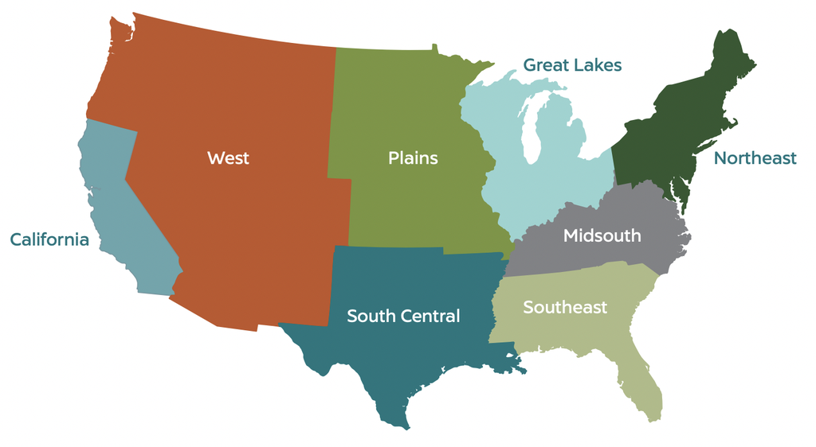

Regions Breakdown by HASS Avocado Board

```python
# California region
california_region = ['California', 'Los Angeles', 'San Diego', 'San Francisco', 'Sacramento']

# West region (excluding California)
west_region = ['Boise', 'Denver', 'Las Vegas', 'Phoenix/Tucson','Portland', 'Seattle', 'Spokane', 'West']

# Plains region
plains_region = ['St. Louis', 'Plains']

# South Central region
south_central_region = ['Dallas/Ft. Worth', 'Houston', 'New Orleans/Mobile',
'South Central', 'West Tex/New Mexico']

# Southeast region
southeast_region = ['Atlanta', 'Charlotte', 'Raleigh/Greensboro', 'Jacksonville','Miami/Ft. Lauderdale', 'Orlando', 'Tampa','South Carolina', 'Southeast']

# Midsouth region
midsouth_region = ['Nashville', 'Louisville', 'Baltimore/Washington','Richmond/Norfolk', 'Roanoke', 'Midsouth']

# Great Lakes region
great_lakes_region = ['Chicago', 'Detroit', 'Grand Rapids', 'Cincinnati/Dayton','Columbus', 'Indianapolis', 'Great Lakes']

# Northeast region
northeast_region = ['New York', 'Albany', 'Buffalo/Rochester', 'Syracuse', 'Boston','Hartford/Springfield', 'Philadelphia', 'Pittsburgh','Harrisburg/Scranton', 'Northern New England', 'Northeast']

def assign_region(x):
    if x in california_region:
        return 'California'
    elif x in west_region:
        return 'West'
    elif x in plains_region:
        return 'Plains'
    elif x in south_central_region:
        return 'South Central'
    elif x in southeast_region:
        return 'Southeast'
    elif x in midsouth_region:
        return 'Midsouth'
    elif x in great_lakes_region:
        return 'Great Lakes'
    elif x in northeast_region:
        return 'Northeast'
    else:
        return None

dfclean['Region'] = dfclean['geography'].apply(assign_region)

region_labels = ['California', 'West', 'Plains', 'South Central',
                 'Southeast', 'Midsouth', 'Great Lakes', 'Northeast']

# Filter out the region rows to avoid double counting
dfcleanf = dfclean[~dfclean['geography'].isin(region_labels)]
```

3. Which major geographical region sold the most total organic, small Hass avocados in 2017?

```python
p = dfcleanf[((dfcleanf['year'] == 2017) & (dfcleanf['type'] == 'organic'))]

region_totals = p.groupby('Region')['Shass'].sum().sort_values(ascending = False)
tregion = region_totals.idxmax() #get region with highest sales
print(region_totals)

print(f"In 2017, the {tregion} region sold the most organic, small Hass avocados.")
```

```
Region
California       1240238.00
West             1078415.51
South Central     993570.02
Northeast         851874.19
Southeast         205116.84
Midsouth          128925.39
Great Lakes        97741.68
Plains             45372.15
Name: Shass, dtype: float64
In 2017, the California region sold the most organic, small Hass avocados.
```

4. Split the date variable into month, day, and year variables. In which month is the highest average volume of avocado sales?

```python
#using the regional grouping dataset
dfcleanf['Year'] = dfcleanf['date'].dt.year #new year column
dfcleanf['Month'] = dfcleanf['date'].dt.month #new month column
dfcleanf['Day'] = dfcleanf['date'].dt.day #new day column

monthly_avg_volume = (
    dfcleanf.groupby('Month')['total_volume']
    .mean()
    .sort_values(ascending=False)
)

hmonth = monthly_avg_volume.idxmax() #get month with highest volume sales
monthname = calendar.month_name[hmonth]

print("Average total avocado volume per month:")
print(monthly_avg_volume)

print(f"The month with the highest average volume of avocado sales is {monthname}.")
```

```
Average total avocado volume per month:
Month
5     329157.166198
2     320319.598579
6     307525.158808
4     296715.682188
3     290129.055634
1     288404.703679
7     286723.500132
8     278325.173936
9     266688.612132
10    249364.581979
11    242971.370124
12    237493.910176
Name: total_volume, dtype: float64
The month with the highest average volume of avocado sales is May.
```

```python
#using the Total U.S. dataset
dfus['Year'] = dfus['date'].dt.year #new year column
dfus['Month'] = dfus['date'].dt.month #new month column
dfus['Day'] = dfus['date'].dt.day #new day column

monthly_avg_volume = (
    dfus.groupby('Month')['total_volume']
    .mean()
    .sort_values(ascending=False)
)

hmonth = monthly_avg_volume.idxmax() #get month with highest volume sales
monthname = calendar.month_name[hmonth]

print("Average total avocado volume per month:")
print(monthly_avg_volume)
print(f"The month with the highest average volume of avocado sales is {monthname}.")
```

```
Average total avocado volume per month:
Month
5     2.293203e+07
2     2.236790e+07
6     2.144947e+07
4     2.077160e+07
3     2.035640e+07
1     2.011432e+07
7     2.009696e+07
8     1.938566e+07
9     1.847439e+07
10    1.719583e+07
11    1.673651e+07
12    1.645596e+07
Name: total_volume, dtype: float64
The month with the highest average volume of avocado sales is May.
```

Whether using the dataset which groups cities and states by their major region or using the Total U.S. dataset it is evident that in May the average volume of avocado sales is highest.

5. Which metro area geographical regions sold the most total avocados? Plot side-by-side box-plots of the total volume for only the five metro geographical regions with the highest averages for the total_volume variable.

```
Top 5 total avocado sales volume by metro area:
geography
Los Angeles         9.593505e+08
New York            5.282452e+08
Dallas/Ft. Worth    4.362042e+08
Houston             4.208438e+08
Phoenix/Tucson      3.825234e+08
Name: total_volume, dtype: float64
Note: HASS Avocado Board when referencing New York does not refer to the state but
rather the NYC metro area
```

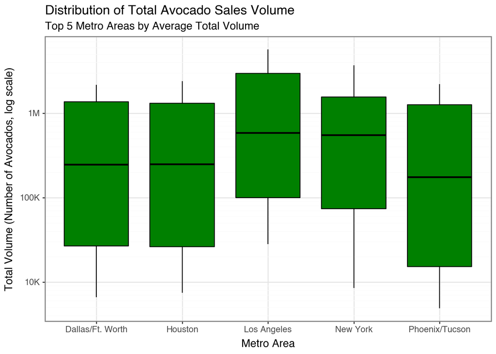

```python
from plotnine import *

metro_top5 = (
    dfcleanf.groupby('geography')['total_volume']
    .sum()
    .sort_values(ascending=False)
    .head(5)
)

print("Top 5 total avocado sales volume by metro area:")
print(metro_top5)

#turns top 5 values into list
top5_list = metro_top5.index.tolist()

df_t5 = dfcleanf[dfcleanf['geography'].isin(top5_list)].copy()

print("Note: HASS Avocado Board when referencing New York does not refer to the state but \nrather the NYC metro area") #this is what I found from HASS

(
  ggplot(df_t5, aes(x='geography', y='total_volume'))
  + geom_boxplot(fill='green',color='black')
  + scale_y_log10(labels=['10K','100K','1M'])  # allows variation to be seen better
  +labs(title = 'Distribution of Total Avocado Sales Volume', subtitle =
  'Top 5 Metro Areas by Average Total Volume', x = 'Metro Area',y='Total Volume (Number of Avocados, log scale)')
  + theme_bw()
)
```

6. From your cleaned data set, create a data set with only these California regions and answer the following questions about these California regions only.

```python
#ca metros
ca_metros = ['Los Angeles', 'San Diego', 'Sacramento', 'San Francisco']

#df of only ca metros
df_ca = dfcleanf[dfcleanf['geography'].isin(ca_metros)].copy()
```

7. In which California regions is the price of organic versus conventional avocados most different? Support your answer with a few summary statistics AND a visualization.

```python
meanprice = (
  df_ca.groupby(['geography', 'type'])['average_price']
  .mean()
  .unstack() #gives two levels of indexing, easier to read, easier for diff calc
  .round(2)
)

meanprice['Difference'] = (meanprice['organic'] - meanprice['conventional']).round(2)

print("Average price by California metro area and type:")
print(meanprice)

mdiff_city = meanprice['Difference'].idxmax()
mdiff_value = meanprice['Difference'].max()

print(f"\nThe price difference between organic and conventional avocados is largest in {mdiff_city} at ${mdiff_value}.")
```

```
Average price by California metro area and type:
type           conventional  organic  Difference
geography
Los Angeles            1.05     1.57        0.52
Sacramento             1.30     1.87        0.57
San Diego              1.11     1.80        0.69
San Francisco          1.40     2.12        0.72

The price difference between organic and conventional avocados is largest in San Francisco at $0.72.
```

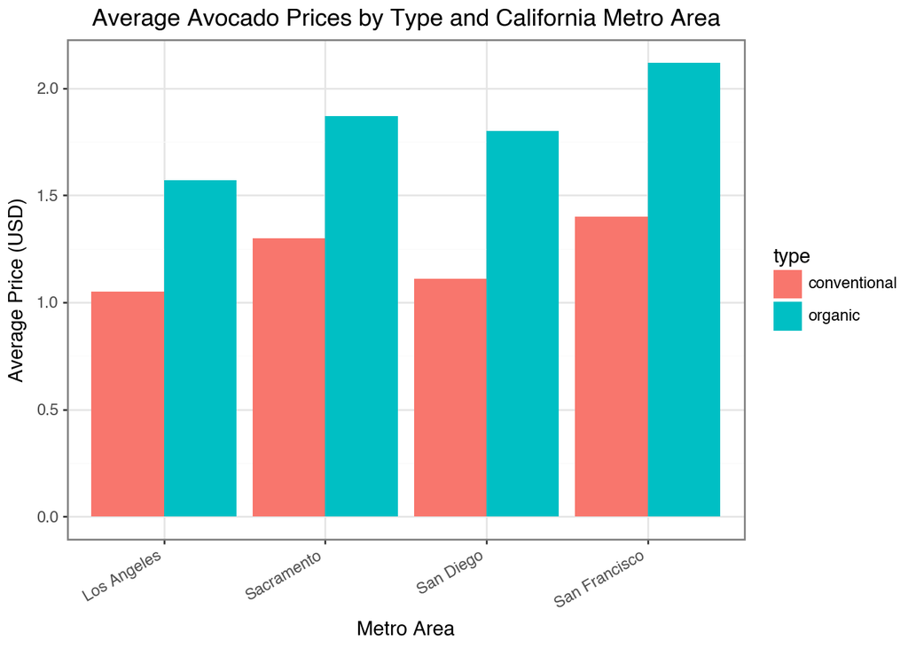

```python
# reset index to get back columns like geography
meanprice = meanprice.reset_index()

#Melt the ca dataframe back to long format
meanprice_long = meanprice.melt(
    id_vars='geography',
    value_vars=['conventional', 'organic'],
    var_name='type',
    value_name='average_price'
)

#grouped bar chart using the ca df
(
    ggplot(meanprice_long, aes(x='geography', y='average_price', fill='type'))
    + geom_col(position='dodge')
    + labs(title='Average Avocado Prices by Type and California Metro Area',x='Metro Area',y='Average Price (USD)')
    + theme_bw()
    + theme(axis_text_x=element_text(rotation=30, ha='right'))#helps look names look better
)
```

8. The following plot shows, for all four California regions, the proportion of the average Hass avocado sales that are small, large, or extra large; conventional vs. organic. Recreate the plot; you do not have to replicate the exact finishing touches - e.g., color, theme - but your plot should resemble the content of this plot.

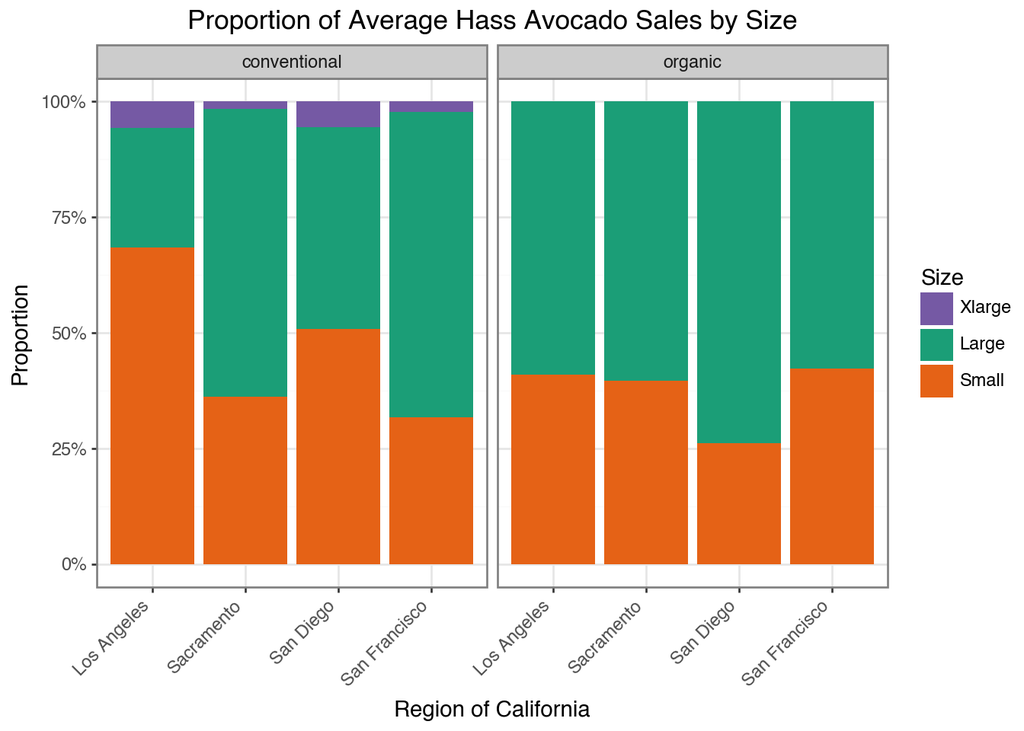

```python
#diff avocado sizes
avosize = ['Shass', "Lhass", "Xlhass"]

#match the order of the cities in example pic by ordering with pandas
order = ['Los Angeles', 'Sacramento', 'San Diego', 'San Francisco']
df_ca['geography'] = pd.Categorical(df_ca['geography'], categories=order, ordered=True)


#average sales grouped by city and type of avocado, per avocado size
mean_sizes = (
    df_ca.groupby(['geography', 'type'])[avosize]
    .mean()
    .reset_index()
)

#this code converts the averages from above into proportions that add up to 1
#for each avocado size group
row_tot = mean_sizes[avosize].sum(axis=1)

props = mean_sizes[avosize].div(row_tot, axis=0)#have to use .div, the / operatior errors out because it cant always do row wise division properly

props.columns = ['Small', 'Large', 'Xlarge']  # nicer labels for the avocado sizes instead of like Shass, Lhass, Xlhass


ca_props = pd.concat(
    [mean_sizes[['geography', 'type']], props],
    axis=1
)

#melt to long format for plotting the graph
plot_df = ca_props.melt(
    id_vars=['geography', 'type'],
    value_vars=['Small', 'Large', 'Xlarge'],
    var_name='Size',
    value_name='proportion'
)

#sorts the sizes from smallest to largest
plot_df['Size'] = pd.Categorical(plot_df['Size'],categories=['Small','Large','Xlarge'],ordered=True)

#legend size order
size_order = ['Xlarge', 'Large', 'Small']

plot_df['proportion'] = plot_df['proportion'] * 100 #get full number for percentage instead of proportions

(
  ggplot(plot_df, aes(x='geography', y='proportion', fill='Size'))
  + geom_col(position=position_stack(reverse=True)) # stack = stacked bars since we're using proportions, reverses ordering of bars to match picture

  + facet_wrap('~type') # this what gives conventional vs organic panels

  + scale_y_continuous(labels=lambda vals: [f"{int(v)}%" for v in vals]) #constant scale for proportions, the lambda function puts a % next to each value in the y axis by going through each value and adding a % to end of string

  +scale_fill_manual(values = {"Small": "#e56216ff","Large": "#1B9E77",
  "Xlarge": "#7559a4ff"}, breaks = size_order) #hex lets you use color picker for colors of bars, breaks sets legend to the order I made earlier without flipping bars

  + labs(title='Proportion of Average Hass Avocado Sales by Size', x='Region of California',y='Proportion')

  + theme_bw()
  + theme(axis_text_x=element_text(rotation=45, ha='right')) #makes city name labels neater like earlier/matches angle of the image
)
```

A joke in the media is that Millennials can’t afford houses, because they spend all their money buying avocado toast. Let’s use this data set to address that claim.

Find or assemble a data set of real data, with house prices for these four California regions. Join this data set with your California avocado data set.

Use your new joined data set to make an argument about the relationship between house prices and avocado prices/sales.

Support your argument with a plot.

```python
#load zillow housing dataset
housing = pd.read_csv('/Users/amritdhillon/Desktop/Computing and Machine Learning for Business Analytics/Week 2/Lab2/statemetro.csv')

#filter for only ca prices
cahome = housing[housing['StateName'] == 'CA']

#cities i wanted to include
include = ['Los Angeles, CA','San Francisco, CA','San Diego, CA','Sacramento, CA']

#filter for cities I want to include and drop irrelevant columns
cahome['RegionName'] = cahome['RegionName'].where(cahome['RegionName'].isin(include))
cahome = cahome.dropna(subset=['RegionName'])
cleanca = cahome.drop(columns='SizeRank')

# Identify the date columns (everything that looks like YYYY-MM-DD) instead of having column for like every date
date_cols = [c for c in cleanca.columns if c[:4].isdigit()]

#melt the dataset to long form
finalhomes = cleanca.melt(
    id_vars=['RegionName','StateName'],
    value_vars=date_cols,
    var_name='Date',
    value_name='Median Home Price'
)

#get years and months column
finalhomes['Date'] = pd.to_datetime(finalhomes['Date'])
finalhomes['year'] = finalhomes['Date'].dt.year
#finalhomes['Month'] = finalhomes['Date'].dt.month #not using anymore

#map values of finalhomes data to avocado data
citymap = {
    'Los Angeles, CA': 'Los Angeles',
    'San Diego, CA': 'San Diego',
    'San Francisco, CA': 'San Francisco',
    'Sacramento, CA': 'Sacramento'
}
finalhomes['geography'] = finalhomes['RegionName'].map(citymap)

#average median home price grouped by metro area and year
yearlyhomes = (
    finalhomes
    .groupby(['geography', 'year'],as_index=False)['Median Home Price']
    .mean()
)

#create new avocado dataset that will be merged with yearlyhomes
avocadoyearly = (
    df_ca.groupby(['geography', 'year'], as_index=False)
         .agg(
             avg_price=('average_price', 'mean'),
             total_volume=('total_volume', 'sum'),
             Shass=('Shass', 'sum'),
             Lhass=('Lhass', 'sum'),
             Xlhass=('Xlhass', 'sum')
         )
)

#merge datasets
dfjoin = pd.merge(avocadoyearly, yearlyhomes, on=['geography', 'year'], how='inner')
```

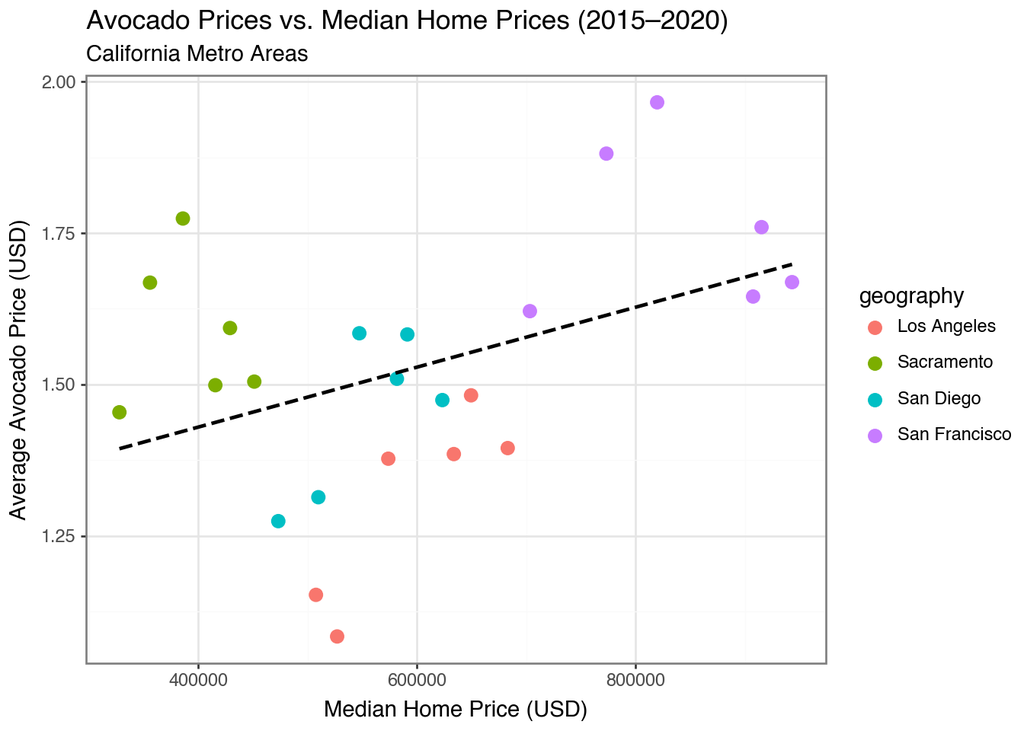

```python
#scatterplot of avocado prices against median home prices
(
    ggplot(dfjoin, aes(x='Median Home Price', y='avg_price',color='geography'))
    + geom_point(size=3)
    + geom_smooth(method='lm', se=False, color='black', linetype='dashed')
    #makes a dashed regression line
    + labs(title='Avocado Prices vs. Median Home Prices (2015–2020)',subtitle='California Metro Areas',x='Median Home Price (USD)',y='Average Avocado Price (USD)')
    + theme_bw()
)
```

This data does not support the claims that millenials are unable to afford homes due to spending too much on avocado toast. By observing four of California’s largest metro areas (Los Angeles, San Diego, San Francisco, and Sacramento) and the avocado prices and housing prices for each, it is evident that higher avocado prices are associated with higher housing prices. This does not represent a causal relationship but rather an effect of the overall cost of living.

The scatterplot shows that average avocado prices per year rise slightly as the median home price of that metro area during that year as well. This is reflected by the fact that San Francisco, the area with the highest median home prices had many of the highest average avocado costs. This pattern is indicative of food and housing both costing more in more urban, high demand areas, not avocado prices raising housing prices.

All in all I believe this data, and this scatterplot show that the average avocado price and median home price are more related by correlation not causation. Avocados do not make homes unaffordable, both prices rising are effects of economic conditions in their metro areas.